# Week 4/5

Evan Wu

#### Code Background

Looking at whiff data for right-handed pitchers (from 2022, 85 pitchers with 1842+ seasonal pitches).

#### Libraries

```r
library(tidyverse)
library(knitr)
library(glmnet)
library(patchwork)
library(olsrr)
```

```r
# Geom Zone (Jackie's) ####

geom_zone <- function(top = 11/3, bottom = 3/2, linecolor = "black"){
  geom_rect(xmin = -.7083, xmax = .7083, ymin = bottom, ymax = top,
            alpha = 0, color = linecolor, linewidth = 0.75)
}

# c(0, 0, -.25, -.5, -.25))

geom_plate <- function(pov = "pitcher"){
   df <- case_when(
     pov == "pitcher" ~
       data.frame(x = c(-.7083, .7083, .7083 ,0, -.7083), y = c(0, 0, .25, .5, .25)),
     pov == "catcher" ~
       data.frame(x = c(-.7083, .7083, .7083 ,0, -.7083), y = c(0, 0, -.25, -.5, -.25))
   )

   g <- geom_polygon(data = df, aes(x = x, y = y), fill = "white", color = "black", linewidth = 1.25)
  g
}

# Barrel Function
is.barrel <- function(LA, EV){
  upper <- 1.11*EV - 78.89
  lower <- -EV + 124
  outcome <- (LA >= lower) & (LA <= upper) & (EV >= 98) & (LA >= 8) & (LA <= 50)
  outcome <- replace_na(outcome, FALSE)
  outcome
}
```

#### Data

Added code to calculate whether a batted ball is a barrel or not. Used code to find the slopes and intercepts for both lines and then inputted rounded coefficients into the model for more simplicity.

Added predicted whiff rate. There were a few hitters with more than 300 pitches of a given pitch type, so for those I used their true whiff percentage.

Also added a strike metric that includes all pitches that can strike a hitter out: called and swinging strikes, as well as foul tips and foul bunts.

```r
rhp <- read_csv("CSVs/rhp_pitches.csv") %>%
  select(-...1) %>%
  filter(!is.na(pfx_z)) %>%
  mutate(distance_sweet = sqrt(((plate_x - 0.85)^2)+((plate_z - 1.55)^2))) %>%
  mutate(zone = case_when(distance < 2 ~ zone,
                          distance >= 2 & plate_z > (sz_top + sz_bot)/2 ~ 16,
                          distance >= 2 & plate_z <= (sz_top + sz_bot)/2 ~ 17)) %>%
  mutate(ab_id = paste0(game_date, "_", player_id, "_", at_bat_number),
         prev_ab_id = lead(ab_id, 1)) %>%
  mutate(prev_pitch = ifelse(ab_id == prev_ab_id, lead(pitch_type, 1), NA)) %>%
  select(-ab_id, -prev_ab_id) %>%
  mutate(prev_pitch = case_when(prev_pitch  %in% c("FF", "FC", "SI") ~ "Fastball",
                                prev_pitch %in% c("SL", "CU", "KC",
                                                  "SV", "ST", "CS") ~ "Breaking Ball",
                                prev_pitch  %in% c("CH", "FS") ~ "Off Speed")) %>%
  mutate(zone = relevel(as.factor(zone), ref = 5))

# New Code for Barrels

# Upper Limit
m <- (50 - 30) / (116 - 98)
b <- 30 - m * 98
paste0("y = ", round(m, 2), "x ", round(b, 2))
```

```
## [1] "y = 1.11x -78.89"
```

```r
# Lower Limit
m <- (8 - 26) / (116 - 98)
b <- 26 - m * 98
paste0("y = ", round(m, 2), "x + ", round(b, 2))
```

```
## [1] "y = -1x + 124"
```

```r
# Barrel
rhp <- rhp %>%
  mutate(Barrel = is.barrel(LA = launch_angle, EV = launch_speed))

# Strike
rhp <- rhp %>%
  mutate(STRIKE = ifelse(description  %in% c("called_strike", "swinging_strike",
                                           "foul_tip", "bunt_foul_tip", "foul_bunt",
                                           "swinging_strike_blocked", "missed_bunt"),
                       1, 0))


# Batter Whiff
batter_stats <- rhp %>%
  summarize(rate = mean(whiff),
                      pitches = n(),
            .by = c(batter, pitch_type)) %>%
  mutate(pitch_whiff = weighted.mean(rate, pitches),
         .by = pitch_type) %>%
  mutate(pred_bwhiff = (pitches / 300)*rate + ((300-pitches)/300)*pitch_whiff) %>%
  mutate(pred_bwhiff = ifelse(pitches >= 300, rate, pred_bwhiff))


# Merging Whiff Prediction with RHP
rhp <- rhp %>%
  left_join(select(batter_stats, batter, pitch_type, pred_bwhiff),
             by = c("batter" = "batter", "pitch_type" = "pitch_type"))

rhp <- rhp %>%
  mutate(prev_pitch = ifelse(is.na(prev_pitch), "None", prev_pitch)) %>%
  mutate(Count = paste0(balls, "-", strikes)) %>%
  mutate(Count = as.factor(Count))


# Barrel
batter_stats2 <- rhp %>%
  summarize(rate = mean(Barrel),
                      pitches = n(),
            .by = c(batter, pitch_type)) %>%
  mutate(pitch_barrel = weighted.mean(rate, pitches),
         .by = pitch_type) %>%
  mutate(pred_bbarrel = (pitches / 300)*rate + ((300-pitches)/300)*pitch_barrel) %>%
  mutate(pred_bbarrel = ifelse(pitches >= 300, rate, pred_bbarrel))

rhp <- rhp %>%
  left_join(select(batter_stats2, batter, pitch_type, pred_bbarrel),
             by = c("batter" = "batter", "pitch_type" = "pitch_type"))


sliders <- rhp %>%
  filter(hitter == "R") %>%
  filter(pitch_type == "SL") %>%
  mutate(count = paste0(balls, "_", strikes),
         prev_pitch = as.factor(prev_pitch)) %>%
  mutate(prev_pitch_ff = ifelse(prev_pitch == "FF", 1, 0))

fastballs <- rhp %>%
  filter(hitter == "R") %>%
  filter(pitch_type == fb_type) %>%
  mutate(count = paste0(balls, "_", strikes),
         prev_pitch = as.factor(prev_pitch))
```

#### WHIFF Slider Initial Model

```r
# Initial Model
sl_model_whiff_all <- glm(whiff ~ pitch_speed + pfx_x + pfx_z + plate_x + plate_z + zone +
              count + pfx_total + speed_change + break_change + distance + prev_pitch +
                speed_fb_diff + pfx_x_fb_diff + pfx_z_fb_diff + release_spin_rate +
                I(plate_x^2) + I(plate_z^2) + pred_bwhiff,
              data = sliders, family = binomial)

# Model Evaluation
summary(sl_model_whiff_all)
```

```
##
## Call:
## glm(formula = whiff ~ pitch_speed + pfx_x + pfx_z + plate_x +
##     plate_z + zone + count + pfx_total + speed_change + break_change +
##     distance + prev_pitch + speed_fb_diff + pfx_x_fb_diff + pfx_z_fb_diff +
##     release_spin_rate + I(plate_x^2) + I(plate_z^2) + pred_bwhiff,
##     family = binomial, data = sliders)
##
## Coefficients:
##                       Estimate Std. Error z value Pr(>|z|)
## (Intercept)          4.443e+00  5.744e+02   0.008 0.993828
## pitch_speed          2.247e-02  1.005e-02   2.236 0.025375 *
## pfx_x                3.364e-01  1.431e-01   2.351 0.018732 *
## pfx_z                4.058e-01  9.589e-02   4.232 2.31e-05 ***
## plate_x              6.416e-01  1.021e-01   6.286 3.25e-10 ***
## plate_z              1.520e+00  1.514e-01  10.039  < 2e-16 ***
## zone1               -1.116e+01  1.218e+02  -0.092 0.926969
## zone2                5.724e-01  3.359e-01   1.704 0.088364 .
## zone3               -9.343e-01  7.289e-01  -1.282 0.199925
## zone4               -5.778e-01  2.810e-01  -2.056 0.039752 *
## zone6                1.657e-01  1.379e-01   1.202 0.229356
## zone7                1.625e-01  2.296e-01   0.708 0.478992
## zone8                3.889e-01  1.380e-01   2.818 0.004833 **
## zone9                7.271e-01  1.304e-01   5.576 2.46e-08 ***
## zone11              -1.091e+01  1.645e+02  -0.066 0.947146
## zone12               2.690e-01  3.194e-01   0.842 0.399632
## zone13               6.837e-01  1.913e-01   3.573 0.000353 ***
## zone14               1.214e+00  1.371e-01   8.854  < 2e-16 ***
## zone16               8.298e-01  1.515e-01   5.478 4.31e-08 ***
## zone17               7.643e-01  2.182e-01   3.502 0.000461 ***
## count0_1            -1.302e+01  5.744e+02  -0.023 0.981916
## count0_2            -1.339e+01  5.744e+02  -0.023 0.981396
## count1_0            -1.312e+01  5.744e+02  -0.023 0.981774
## count1_1            -1.295e+01  5.744e+02  -0.023 0.982011
## count1_2            -1.320e+01  5.744e+02  -0.023 0.981667
## count2_0            -1.289e+01  5.744e+02  -0.022 0.982099
## count2_1            -1.274e+01  5.744e+02  -0.022 0.982300
## count2_2            -1.317e+01  5.744e+02  -0.023 0.981705
## count3_0            -1.398e+01  5.744e+02  -0.024 0.980576
## count3_1            -1.301e+01  5.744e+02  -0.023 0.981929
```

[output cut: 11 more lines]

```
## release_spin_rate    3.618e-04  9.839e-05   3.677 0.000236 ***
## I(plate_x^2)        -1.526e-02  8.263e-02  -0.185 0.853503
## I(plate_z^2)        -1.247e-01  6.352e-02  -1.963 0.049620 *
## pred_bwhiff          1.805e+01  9.338e-01  19.324  < 2e-16 ***
## ---
## Signif. codes:  0 '***' 0.001 '**' 0.01 '*' 0.05 '.' 0.1 ' ' 1
##
## (Dispersion parameter for binomial family taken to be 1)
##
##     Null deviance: 19130  on 22074  degrees of freedom
## Residual deviance: 17099  on 22030  degrees of freedom
##   (31 observations deleted due to missingness)
## AIC: 17189
##
## Number of Fisher Scoring iterations: 13
```

#### WHIFF Slider Refined Model & Predictions

Variables Removed:

count

plate_x^2

pfx_x_fb_diff

pfx_z_fb_diff

```r
# Refined Model
sl_model_whiff <- glm(whiff ~ pitch_speed + pfx_x + pfx_z + plate_x + plate_z + zone +
              pfx_total + speed_change + break_change + distance + prev_pitch +
                speed_fb_diff + release_spin_rate +
                I(plate_z^2) + pred_bwhiff,
              data = sliders, family = binomial)

# Model Evaluation
summary(sl_model_whiff)
```

```
##
## Call:
## glm(formula = whiff ~ pitch_speed + pfx_x + pfx_z + plate_x +
##     plate_z + zone + pfx_total + speed_change + break_change +
##     distance + prev_pitch + speed_fb_diff + release_spin_rate +
##     I(plate_z^2) + pred_bwhiff, family = binomial, data = sliders)
##
## Coefficients:
##                       Estimate Std. Error z value Pr(>|z|)
## (Intercept)         -8.424e+00  8.976e-01  -9.385  < 2e-16 ***
## pitch_speed          1.942e-02  9.627e-03   2.017 0.043671 *
## pfx_x                3.112e-01  1.328e-01   2.342 0.019160 *
## pfx_z                4.578e-01  8.758e-02   5.228 1.72e-07 ***
## plate_x              6.143e-01  9.586e-02   6.408 1.48e-10 ***
## plate_z              1.537e+00  1.470e-01  10.453  < 2e-16 ***
## zone1               -1.118e+01  1.216e+02  -0.092 0.926724
## zone2                5.663e-01  3.354e-01   1.689 0.091276 .
## zone3               -9.381e-01  7.284e-01  -1.288 0.197813
## zone4               -5.795e-01  2.797e-01  -2.072 0.038256 *
## zone6                1.665e-01  1.375e-01   1.211 0.225912
## zone7                1.536e-01  2.264e-01   0.678 0.497498
## zone8                3.751e-01  1.366e-01   2.745 0.006053 **
## zone9                7.230e-01  1.300e-01   5.562 2.67e-08 ***
## zone11              -1.093e+01  1.645e+02  -0.066 0.947038
## zone12               2.763e-01  3.187e-01   0.867 0.385955
## zone13               6.505e-01  1.808e-01   3.598 0.000320 ***
## zone14               1.203e+00  1.355e-01   8.881  < 2e-16 ***
## zone16               8.143e-01  1.490e-01   5.466 4.60e-08 ***
## zone17               7.229e-01  1.957e-01   3.693 0.000222 ***
## pfx_total           -6.552e-01  1.498e-01  -4.374 1.22e-05 ***
## speed_change         5.578e-02  2.139e-02   2.608 0.009107 **
## break_change         4.815e-01  1.526e-01   3.155 0.001605 **
## distance            -1.709e+00  1.218e-01 -14.025  < 2e-16 ***
## prev_pitchFastball  -1.397e-01  4.505e-02  -3.101 0.001926 **
## prev_pitchNone      -3.438e-01  5.360e-02  -6.415 1.41e-10 ***
## prev_pitchOff Speed -6.358e-03  9.802e-02  -0.065 0.948282
## speed_fb_diff       -6.643e-02  1.187e-02  -5.596 2.20e-08 ***
## release_spin_rate    3.817e-04  9.683e-05   3.943 8.06e-05 ***
## I(plate_z^2)        -1.218e-01  5.389e-02  -2.261 0.023776 *
## pred_bwhiff          1.783e+01  9.300e-01  19.170  < 2e-16 ***
## ---
## Signif. codes:  0 '***' 0.001 '**' 0.01 '*' 0.05 '.' 0.1 ' ' 1
##
## (Dispersion parameter for binomial family taken to be 1)
##
##     Null deviance: 19130  on 22074  degrees of freedom
## Residual deviance: 17155  on 22044  degrees of freedom
##   (31 observations deleted due to missingness)
## AIC: 17217
##
## Number of Fisher Scoring iterations: 13
```

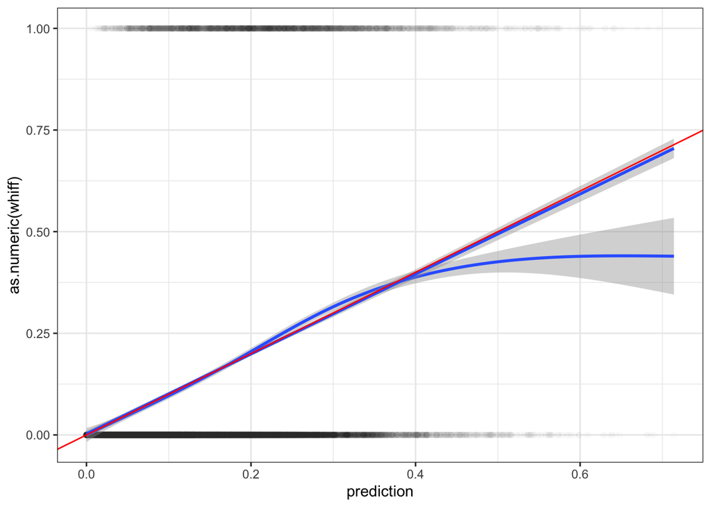

```r
# Model Predictions
sl_preds_whiff <- sliders %>%
  mutate(prediction_log = predict(sl_model_whiff, sliders),
         prediction = 1 / (1 + exp(-prediction_log)),
         rounded_pred = case_when(
           prediction >= 0.5 ~ 1,
           prediction < 0.5 ~ 0
         )) %>%
  filter(!is.na(prediction))

ggplot(sl_preds_whiff, aes(x = prediction, y = as.numeric(whiff))) +
  geom_point(alpha = 0.01) +
  geom_smooth() +
  geom_smooth(method = "lm") +
  geom_abline(slope = 1, intercept = 0, color = "red") +
  theme_bw()
```

Slider Refined Model:

The model seems to be accurate the expected proportion of the time, except after around 0.4. Coincidentally, this is around where the observations thin out. This could possibly be a result of a lack of datapoints?

#### WHIFF Fastball Initial Model

```r
# Initial Model
fb_model_whiff_all <- glm(whiff ~ pitch_speed + pfx_x + pfx_z + plate_x + plate_z + zone +
              count + pfx_total + speed_change + break_change + distance + prev_pitch +
                release_spin_rate + I(plate_x^2) + I(plate_z^2) + pred_bwhiff,
              data = fastballs, family = binomial)

# Model Evaluation
summary(fb_model_whiff_all)
```

```
##
## Call:
## glm(formula = whiff ~ pitch_speed + pfx_x + pfx_z + plate_x +
##     plate_z + zone + count + pfx_total + speed_change + break_change +
##     distance + prev_pitch + release_spin_rate + I(plate_x^2) +
##     I(plate_z^2) + pred_bwhiff, family = binomial, data = fastballs)
##
## Coefficients:
##                       Estimate Std. Error z value Pr(>|z|)
## (Intercept)         -7.188e+00  1.195e+02  -0.060 0.952022
## pitch_speed          5.569e-02  7.867e-03   7.079 1.45e-12 ***
## pfx_x                6.395e-01  8.086e-02   7.908 2.61e-15 ***
## pfx_z               -1.161e+00  1.174e-01  -9.886  < 2e-16 ***
## plate_x             -1.143e-01  3.787e-02  -3.018 0.002545 **
## plate_z              2.469e+00  2.605e-01   9.476  < 2e-16 ***
## zone1               -1.830e-02  3.019e-01  -0.061 0.951681
## zone2               -1.888e-01  1.815e-01  -1.040 0.298172
## zone3                5.693e-01  2.156e-01   2.641 0.008268 **
## zone4               -4.445e-01  1.138e-01  -3.905 9.42e-05 ***
## zone6                2.584e-01  8.431e-02   3.065 0.002175 **
## zone7                2.522e-01  1.426e-01   1.769 0.076898 .
## zone8               -3.708e-02  1.254e-01  -0.296 0.767469
## zone9               -1.495e-02  1.248e-01  -0.120 0.904609
## zone11              -3.536e-01  3.959e-01  -0.893 0.371740
## zone12               3.710e-01  2.406e-01   1.542 0.122988
## zone13               1.086e+00  1.300e-01   8.352  < 2e-16 ***
## zone14               5.298e-01  1.226e-01   4.322 1.54e-05 ***
## zone16               3.399e-01  7.797e-02   4.359 1.31e-05 ***
## zone17               8.566e-01  2.356e-01   3.636 0.000277 ***
## count0_1            -6.600e+00  1.195e+02  -0.055 0.955946
## count0_2            -6.856e+00  1.195e+02  -0.057 0.954236
## count1_0            -6.783e+00  1.195e+02  -0.057 0.954720
## count1_1            -6.587e+00  1.195e+02  -0.055 0.956029
## count1_2            -6.633e+00  1.195e+02  -0.056 0.955720
## count2_0            -6.812e+00  1.195e+02  -0.057 0.954531
## count2_1            -6.554e+00  1.195e+02  -0.055 0.956250
## count2_2            -6.630e+00  1.195e+02  -0.055 0.955742
## count3_0            -8.683e+00  1.195e+02  -0.073 0.942064
## count3_1            -6.868e+00  1.195e+02  -0.057 0.954156
## count3_2            -6.848e+00  1.195e+02  -0.057 0.954290
## pfx_total            8.422e-01  1.824e-01   4.617 3.90e-06 ***
## speed_change         9.349e-02  2.184e-02   4.282 1.85e-05 ***
## break_change         1.498e+00  1.692e-01   8.857  < 2e-16 ***
## distance             8.861e-01  2.711e-01   3.269 0.001080 **
## prev_pitchFastball   5.605e-02  4.368e-02   1.283 0.199446
## prev_pitchNone      -7.069e+00  1.195e+02  -0.059 0.952818
## prev_pitchOff Speed  3.290e-02  8.462e-02   0.389 0.697475
## release_spin_rate    4.969e-04  1.153e-04   4.310 1.64e-05 ***
## I(plate_x^2)        -9.566e-01  7.822e-02 -12.230  < 2e-16 ***
## I(plate_z^2)        -5.078e-01  3.417e-02 -14.859  < 2e-16 ***
## pred_bwhiff          1.750e+01  6.857e-01  25.529  < 2e-16 ***
## ---
## Signif. codes:  0 '***' 0.001 '**' 0.01 '*' 0.05 '.' 0.1 ' ' 1
##
## (Dispersion parameter for binomial family taken to be 1)
##
##     Null deviance: 25315  on 42647  degrees of freedom
## Residual deviance: 22597  on 42606  degrees of freedom
##   (129 observations deleted due to missingness)
## AIC: 22681
##
## Number of Fisher Scoring iterations: 9
```

#### WHIFF Fastball Refined Model & Predictions

Variables Removed:

count

```r
# Refined Model
fb_model_whiff <- glm(whiff ~ pitch_speed + pfx_x + pfx_z + plate_x + plate_z + zone +
              pfx_total + speed_change + break_change + distance + prev_pitch +
                release_spin_rate + I(plate_x^2) + I(plate_z^2) + pred_bwhiff,
              data = fastballs, family = binomial)

# Model Evaluation
summary(fb_model_whiff)
```

```
##
## Call:
## glm(formula = whiff ~ pitch_speed + pfx_x + pfx_z + plate_x +
##     plate_z + zone + pfx_total + speed_change + break_change +
##     distance + prev_pitch + release_spin_rate + I(plate_x^2) +
##     I(plate_z^2) + pred_bwhiff, family = binomial, data = fastballs)
##
## Coefficients:
##                       Estimate Std. Error z value Pr(>|z|)
## (Intercept)         -1.383e+01  7.984e-01 -17.322  < 2e-16 ***
## pitch_speed          5.485e-02  7.848e-03   6.989 2.78e-12 ***
## pfx_x                6.271e-01  8.059e-02   7.781 7.19e-15 ***
## pfx_z               -1.147e+00  1.172e-01  -9.781  < 2e-16 ***
## plate_x             -1.152e-01  3.766e-02  -3.060 0.002213 **
## plate_z              2.466e+00  2.602e-01   9.475  < 2e-16 ***
## zone1               -5.344e-02  3.016e-01  -0.177 0.859351
## zone2               -1.914e-01  1.812e-01  -1.056 0.290829
## zone3                5.644e-01  2.147e-01   2.628 0.008579 **
## zone4               -4.397e-01  1.137e-01  -3.867 0.000110 ***
## zone6                2.620e-01  8.413e-02   3.114 0.001844 **
## zone7                2.589e-01  1.424e-01   1.818 0.069089 .
## zone8               -4.390e-02  1.253e-01  -0.350 0.725970
## zone9               -2.322e-02  1.247e-01  -0.186 0.852206
## zone11              -3.372e-01  3.957e-01  -0.852 0.394027
## zone12               3.818e-01  2.397e-01   1.593 0.111260
## zone13               1.098e+00  1.298e-01   8.460  < 2e-16 ***
## zone14               5.310e-01  1.224e-01   4.339 1.43e-05 ***
## zone16               3.454e-01  7.780e-02   4.439 9.02e-06 ***
## zone17               8.498e-01  2.353e-01   3.612 0.000303 ***
## pfx_total            8.260e-01  1.820e-01   4.537 5.69e-06 ***
## speed_change         1.022e-01  2.094e-02   4.881 1.06e-06 ***
## break_change         1.481e+00  1.686e-01   8.786  < 2e-16 ***
## distance             8.610e-01  2.702e-01   3.187 0.001440 **
## prev_pitchFastball   2.779e-02  4.328e-02   0.642 0.520748
## prev_pitchNone      -3.742e-01  5.223e-02  -7.165 7.80e-13 ***
## prev_pitchOff Speed  2.512e-02  8.406e-02   0.299 0.765015
## release_spin_rate    5.119e-04  1.151e-04   4.449 8.64e-06 ***
## I(plate_x^2)        -9.393e-01  7.785e-02 -12.065  < 2e-16 ***
## I(plate_z^2)        -5.032e-01  3.402e-02 -14.788  < 2e-16 ***
## pred_bwhiff          1.754e+01  6.831e-01  25.672  < 2e-16 ***
## ---
## Signif. codes:  0 '***' 0.001 '**' 0.01 '*' 0.05 '.' 0.1 ' ' 1
##
## (Dispersion parameter for binomial family taken to be 1)
##
##     Null deviance: 25315  on 42647  degrees of freedom
## Residual deviance: 22701  on 42617  degrees of freedom
##   (129 observations deleted due to missingness)
## AIC: 22763
##
## Number of Fisher Scoring iterations: 6
```

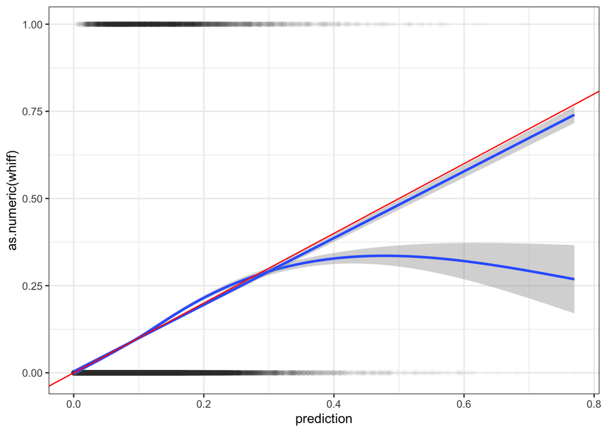

```r
# Model Predictions
fb_preds_whiff <- fastballs %>%
  mutate(prediction_log = predict(fb_model_whiff, fastballs),
         prediction = 1 / (1 + exp(-prediction_log)),
         rounded_pred = case_when(
           prediction >= 0.5 ~ 1,
           prediction < 0.5 ~ 0
         )) %>%
  filter(!is.na(prediction))

ggplot(fb_preds_whiff, aes(x = prediction, y = as.numeric(whiff))) +
  geom_point(alpha = 0.01) +
  geom_smooth() +
  geom_smooth(method = "lm") +
  geom_abline(slope = 1, intercept = 0, color = "red") +
  theme_bw()
```

Refined Fastball Model:

#### BARREL Slider Initial Model

```r
# Initial Model
sl_model_barrel_all <- glm(Barrel ~ pitch_speed + pfx_x + pfx_z + plate_x + plate_z + zone +
              count + pfx_total + speed_change + break_change + distance + prev_pitch +
                speed_fb_diff + pfx_x_fb_diff + pfx_z_fb_diff + release_spin_rate +
                I(plate_x^2) + I(plate_z^2) + pred_bbarrel,
              data = sliders, family = binomial)
# Model Evaluation
summary(sl_model_barrel_all)
```

```
##
## Call:
## glm(formula = Barrel ~ pitch_speed + pfx_x + pfx_z + plate_x +
##     plate_z + zone + count + pfx_total + speed_change + break_change +
##     distance + prev_pitch + speed_fb_diff + pfx_x_fb_diff + pfx_z_fb_diff +
##     release_spin_rate + I(plate_x^2) + I(plate_z^2) + pred_bbarrel,
##     family = binomial, data = sliders)
##
## Coefficients:
##                       Estimate Std. Error z value Pr(>|z|)
## (Intercept)          4.032e+00  1.080e+04   0.000  0.99970
## pitch_speed         -8.130e-02  3.146e-02  -2.584  0.00976 **
## pfx_x               -4.695e-01  4.556e-01  -1.031  0.30271
## pfx_z               -3.677e-01  3.051e-01  -1.205  0.22814
## plate_x             -4.771e-01  3.094e-01  -1.542  0.12311
## plate_z              9.302e+00  2.023e+00   4.598 4.26e-06 ***
## zone1               -1.700e+01  2.373e+03  -0.007  0.99429
## zone2                6.807e-02  5.496e-01   0.124  0.90143
## zone3                3.181e-01  7.726e-01   0.412  0.68056
## zone4                2.767e-01  3.021e-01   0.916  0.35976
## zone6                2.462e-01  2.620e-01   0.940  0.34743
## zone7                6.256e-01  3.748e-01   1.669  0.09512 .
## zone8               -3.063e-01  2.976e-01  -1.029  0.30331
## zone9               -3.190e-01  3.440e-01  -0.927  0.35382
## zone11              -1.579e+01  3.254e+03  -0.005  0.99613
## zone12              -1.490e+01  1.452e+03  -0.010  0.99182
## zone13              -1.485e+00  1.103e+00  -1.346  0.17842
## zone14              -1.448e+00  7.447e-01  -1.945  0.05178 .
## zone16               1.159e-01  3.694e-01   0.314  0.75369
## zone17              -9.699e+00  3.042e+02  -0.032  0.97457
## count0_1            -1.211e+01  1.080e+04  -0.001  0.99911
## count0_2            -1.141e+01  1.080e+04  -0.001  0.99916
## count1_0            -1.202e+01  1.080e+04  -0.001  0.99911
## count1_1            -1.210e+01  1.080e+04  -0.001  0.99911
## count1_2            -1.167e+01  1.080e+04  -0.001  0.99914
## count2_0            -1.276e+01  1.080e+04  -0.001  0.99906
## count2_1            -1.146e+01  1.080e+04  -0.001  0.99915
## count2_2            -1.158e+01  1.080e+04  -0.001  0.99914
## count3_0            -2.877e+01  1.114e+04  -0.003  0.99794
## count3_1            -1.163e+01  1.080e+04  -0.001  0.99914
```

[output cut: 11 more lines]

```
## release_spin_rate   -6.392e-06  3.405e-04  -0.019  0.98502
## I(plate_x^2)        -1.734e+00  5.909e-01  -2.935  0.00334 **
## I(plate_z^2)        -1.626e+00  3.692e-01  -4.404 1.06e-05 ***
## pred_bbarrel         1.606e+02  1.122e+01  14.309  < 2e-16 ***
## ---
## Signif. codes:  0 '***' 0.001 '**' 0.01 '*' 0.05 '.' 0.1 ' ' 1
##
## (Dispersion parameter for binomial family taken to be 1)
##
##     Null deviance: 2844.2  on 22074  degrees of freedom
## Residual deviance: 2094.7  on 22030  degrees of freedom
##   (31 observations deleted due to missingness)
## AIC: 2184.7
##
## Number of Fisher Scoring iterations: 19
```

#### BARREL Slider Refined Model & Predictions

Variables Removed:

count

pfx_x_fb_diff

release_spin_rate

pfx_z_fb_diff

pfx_total

pfx_x

pfx_z

speed_change

plate_x

break_change

distance

```r
# Refined Model
sl_model_barrel <- glm(Barrel ~ pitch_speed + plate_z + zone +
              prev_pitch + speed_fb_diff + I(plate_x^2) + I(plate_z^2) + pred_bbarrel,
              data = sliders, family = binomial)
# Model Evaluation
summary(sl_model_barrel)
```

```
##
## Call:
## glm(formula = Barrel ~ pitch_speed + plate_z + zone + prev_pitch +
##     speed_fb_diff + I(plate_x^2) + I(plate_z^2) + pred_bbarrel,
##     family = binomial, data = sliders)
##
## Coefficients:
##                       Estimate Std. Error z value Pr(>|z|)
## (Intercept)           -6.37678    3.33747  -1.911  0.05605 .
## pitch_speed           -0.08682    0.02826  -3.072  0.00213 **
## plate_z                7.77726    1.71308   4.540 5.63e-06 ***
## zone1                -16.78699 2408.81261  -0.007  0.99444
## zone2                 -0.02943    0.53964  -0.055  0.95650
## zone3                 -0.03246    0.75275  -0.043  0.96560
## zone4                  0.56684    0.25581   2.216  0.02670 *
## zone6                  0.01452    0.22840   0.064  0.94932
## zone7                  0.92373    0.33364   2.769  0.00563 **
## zone8                 -0.19990    0.28102  -0.711  0.47687
## zone9                 -0.47329    0.31785  -1.489  0.13648
## zone11               -15.34991 3266.02762  -0.005  0.99625
## zone12               -15.30256 1458.54579  -0.010  0.99163
## zone13                -0.99353    1.09711  -0.906  0.36515
## zone14                -1.72640    0.73285  -2.356  0.01849 *
## zone16                 0.02342    0.35954   0.065  0.94807
## zone17                -9.89246  300.58653  -0.033  0.97375
## prev_pitchFastball     0.11883    0.15031   0.791  0.42919
## prev_pitchNone        -0.41862    0.17963  -2.330  0.01978 *
## prev_pitchOff Speed    0.12959    0.31370   0.413  0.67953
## speed_fb_diff          0.08367    0.03583   2.336  0.01952 *
## I(plate_x^2)          -2.38766    0.43937  -5.434 5.50e-08 ***
## I(plate_z^2)          -1.61286    0.36091  -4.469 7.86e-06 ***
## pred_bbarrel         160.08036   11.03211  14.510  < 2e-16 ***
## ---
## Signif. codes:  0 '***' 0.001 '**' 0.01 '*' 0.05 '.' 0.1 ' ' 1
##
## (Dispersion parameter for binomial family taken to be 1)
##
##     Null deviance: 2844.6  on 22092  degrees of freedom
## Residual deviance: 2131.5  on 22069  degrees of freedom
##   (13 observations deleted due to missingness)
## AIC: 2179.5
##
## Number of Fisher Scoring iterations: 19
```

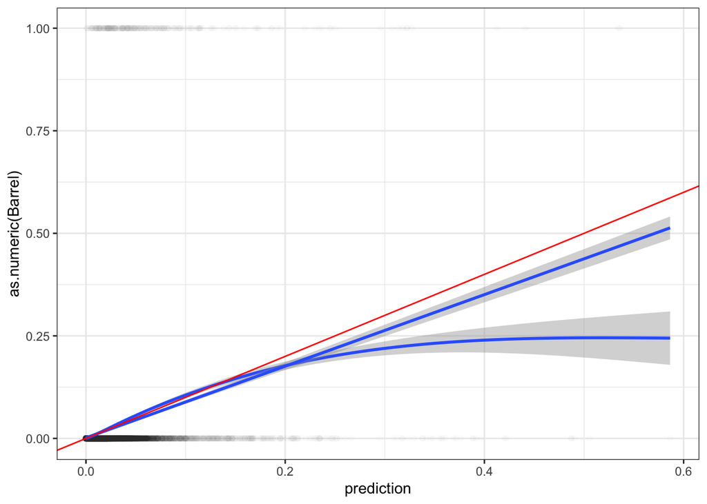

```r
# Model Predictions
sl_preds_barrel <- sliders %>%
  mutate(prediction_log = predict(sl_model_barrel, sliders),
         prediction = 1 / (1 + exp(-prediction_log)),
         rounded_pred = case_when(
           prediction >= 0.5 ~ 1,
           prediction < 0.5 ~ 0
         )) %>%
  filter(!is.na(prediction))

ggplot(sl_preds_barrel, aes(x = prediction, y = as.numeric(Barrel))) +
  geom_point(alpha = 0.01) +
  geom_smooth() +
  geom_smooth(method = "lm") +
  geom_abline(slope = 1, intercept = 0, color = "red") +
  theme_bw()
```

Refined Slider Model:

#### BARREL Fastball Initial Model

```r
# Initial Model
fb_model_barrel_all <- glm(Barrel ~ pitch_speed + pfx_x + pfx_z + plate_x + plate_z + zone +
              count + pfx_total + speed_change + break_change + distance + prev_pitch +
                release_spin_rate + I(plate_x^2) + I(plate_z^2) + pred_bbarrel,
              data = fastballs, family = binomial)
# Model Evaluation
summary(fb_model_barrel_all)
```

```
##
## Call:
## glm(formula = Barrel ~ pitch_speed + pfx_x + pfx_z + plate_x +
##     plate_z + zone + count + pfx_total + speed_change + break_change +
##     distance + prev_pitch + release_spin_rate + I(plate_x^2) +
##     I(plate_z^2) + pred_bbarrel, family = binomial, data = fastballs)
##
## Coefficients:
##                       Estimate Std. Error z value Pr(>|z|)
## (Intercept)          1.288e+01  1.773e+04   0.001  0.99942
## pitch_speed         -9.053e-02  1.762e-02  -5.137 2.79e-07 ***
## pfx_x               -1.070e-01  2.060e-01  -0.520  0.60334
## pfx_z                3.491e-01  2.948e-01   1.184  0.23643
## plate_x             -2.510e-02  1.263e-01  -0.199  0.84246
## plate_z              6.399e+00  9.741e-01   6.569 5.06e-11 ***
## zone1                2.434e-01  4.405e-01   0.553  0.58058
## zone2               -1.213e-01  2.799e-01  -0.433  0.66492
## zone3               -3.277e-01  5.238e-01  -0.626  0.53157
## zone4                3.533e-01  1.555e-01   2.272  0.02308 *
## zone6               -1.064e-01  1.549e-01  -0.687  0.49231
## zone7                4.866e-01  2.424e-01   2.008  0.04468 *
## zone8               -2.585e-01  2.162e-01  -1.196  0.23182
## zone9               -5.997e-01  2.718e-01  -2.206  0.02737 *
## zone11               9.451e-01  5.062e-01   1.867  0.06186 .
## zone12              -1.146e+00  1.027e+00  -1.117  0.26410
## zone13               6.061e-01  3.437e-01   1.763  0.07785 .
## zone14              -1.473e+01  2.133e+02  -0.069  0.94495
## zone16              -9.024e-02  1.632e-01  -0.553  0.58035
## zone17              -1.342e+01  5.207e+02  -0.026  0.97943
## count0_1            -1.667e+01  1.773e+04  -0.001  0.99925
## count0_2            -1.657e+01  1.773e+04  -0.001  0.99925
## count1_0            -1.669e+01  1.773e+04  -0.001  0.99925
## count1_1            -1.648e+01  1.773e+04  -0.001  0.99926
## count1_2            -1.637e+01  1.773e+04  -0.001  0.99926
## count2_0            -1.629e+01  1.773e+04  -0.001  0.99927
## count2_1            -1.625e+01  1.773e+04  -0.001  0.99927
## count2_2            -1.606e+01  1.773e+04  -0.001  0.99928
## count3_0            -1.680e+01  1.773e+04  -0.001  0.99924
## count3_1            -1.609e+01  1.773e+04  -0.001  0.99928
## count3_2            -1.615e+01  1.773e+04  -0.001  0.99927
## pfx_total           -1.383e-01  4.349e-01  -0.318  0.75039
## speed_change        -9.596e-02  4.564e-02  -2.103  0.03550 *
## break_change        -9.381e-01  3.748e-01  -2.503  0.01231 *
## distance            -2.464e-02  7.676e-01  -0.032  0.97440
## prev_pitchFastball   6.259e-02  9.519e-02   0.657  0.51089
## prev_pitchNone      -1.694e+01  1.773e+04  -0.001  0.99924
## prev_pitchOff Speed -1.566e-01  1.823e-01  -0.859  0.39039
## release_spin_rate   -6.840e-04  2.429e-04  -2.816  0.00486 **
## I(plate_x^2)        -1.680e+00  2.645e-01  -6.351 2.14e-10 ***
## I(plate_z^2)        -1.226e+00  1.416e-01  -8.656  < 2e-16 ***
## pred_bbarrel         1.092e+02  5.886e+00  18.558  < 2e-16 ***
## ---
## Signif. codes:  0 '***' 0.001 '**' 0.01 '*' 0.05 '.' 0.1 ' ' 1
##
## (Dispersion parameter for binomial family taken to be 1)
##
##     Null deviance: 7337.6  on 42647  degrees of freedom
## Residual deviance: 6176.4  on 42606  degrees of freedom
##   (129 observations deleted due to missingness)
## AIC: 6260.4
##
## Number of Fisher Scoring iterations: 19
```

#### BARREL Fastball Refined Model & Predictions

Variables Removed:

count

pfx_total

plate_x

pfx_x

distance

```r
# Refined Model
fb_model_barrel <- glm(Barrel ~ pitch_speed + pfx_z + plate_z + zone +
              break_change + prev_pitch +
                release_spin_rate + I(plate_x^2) + I(plate_z^2) + pred_bbarrel,
              data = fastballs, family = binomial)
# Model Evaluation
summary(fb_model_barrel)
```

```
##
## Call:
## glm(formula = Barrel ~ pitch_speed + pfx_z + plate_z + zone +
##     break_change + prev_pitch + release_spin_rate + I(plate_x^2) +
##     I(plate_z^2) + pred_bbarrel, family = binomial, data = fastballs)
##
## Coefficients:
##                       Estimate Std. Error z value Pr(>|z|)
## (Intercept)         -3.162e+00  1.843e+00  -1.716  0.08615 .
## pitch_speed         -9.426e-02  1.578e-02  -5.973 2.33e-09 ***
## pfx_z                2.661e-01  1.148e-01   2.318  0.02045 *
## plate_z              6.443e+00  7.870e-01   8.186 2.70e-16 ***
## zone1                2.950e-01  4.329e-01   0.681  0.49556
## zone2               -1.008e-01  2.751e-01  -0.366  0.71409
## zone3               -3.444e-01  5.174e-01  -0.666  0.50560
## zone4                3.828e-01  1.435e-01   2.666  0.00767 **
## zone6               -1.175e-01  1.420e-01  -0.827  0.40816
## zone7                5.076e-01  2.304e-01   2.203  0.02758 *
## zone8               -2.386e-01  2.096e-01  -1.138  0.25503
## zone9               -6.065e-01  2.657e-01  -2.282  0.02246 *
## zone11               9.954e-01  4.930e-01   2.019  0.04347 *
## zone12              -1.159e+00  1.019e+00  -1.138  0.25506
## zone13               6.362e-01  3.269e-01   1.946  0.05164 .
## zone14              -1.476e+01  2.143e+02  -0.069  0.94508
## zone16              -8.768e-02  1.585e-01  -0.553  0.58021
## zone17              -1.342e+01  5.201e+02  -0.026  0.97942
## break_change        -1.033e+00  3.281e-01  -3.149  0.00164 **
## prev_pitchFastball   3.964e-02  9.418e-02   0.421  0.67385
## prev_pitchNone      -5.057e-01  1.125e-01  -4.496 6.93e-06 ***
## prev_pitchOff Speed -8.653e-02  1.807e-01  -0.479  0.63203
## release_spin_rate   -7.331e-04  2.316e-04  -3.165  0.00155 **
## I(plate_x^2)        -1.702e+00  1.817e-01  -9.364  < 2e-16 ***
## I(plate_z^2)        -1.237e+00  1.391e-01  -8.892  < 2e-16 ***
## pred_bbarrel         1.081e+02  5.754e+00  18.788  < 2e-16 ***
## ---
## Signif. codes:  0 '***' 0.001 '**' 0.01 '*' 0.05 '.' 0.1 ' ' 1
##
## (Dispersion parameter for binomial family taken to be 1)
##
##     Null deviance: 7339.0  on 42689  degrees of freedom
## Residual deviance: 6207.4  on 42664  degrees of freedom
##   (87 observations deleted due to missingness)
## AIC: 6259.4
##
## Number of Fisher Scoring iterations: 19
```

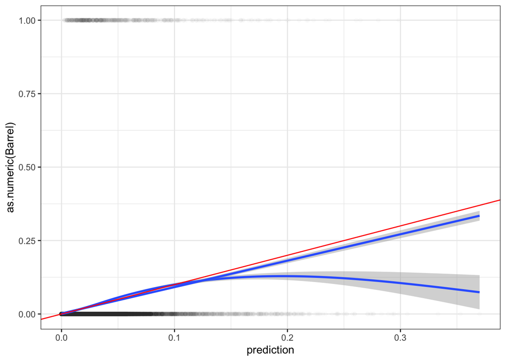

```r
# Model Predictions
fb_preds_barrel <- fastballs %>%
  mutate(prediction_log = predict(fb_model_barrel, fastballs),
         prediction = 1 / (1 + exp(-prediction_log)),
         rounded_pred = case_when(
           prediction >= 0.5 ~ 1,
           prediction < 0.5 ~ 0
         )) %>%
  filter(!is.na(prediction))

ggplot(fb_preds_barrel, aes(x = prediction, y = as.numeric(Barrel))) +
  geom_point(alpha = 0.01) +
  geom_smooth() +
  geom_smooth(method = "lm") +
  geom_abline(slope = 1, intercept = 0, color = "red") +
  theme_bw()
```

Refined Fastball Model:

#### STRIKE Slider Initial Model

```r
# Initial Model
sl_model_strike_all <- glm(STRIKE ~ pitch_speed + pfx_x + pfx_z + plate_x + plate_z + zone +
              count + pfx_total + speed_change + break_change + distance + prev_pitch +
                speed_fb_diff + pfx_x_fb_diff + pfx_z_fb_diff + release_spin_rate +
                I(plate_x^2) + I(plate_z^2),
              data = sliders, family = binomial)

# Model Evaluation
summary(sl_model_strike_all)
```

```
##
## Call:
## glm(formula = STRIKE ~ pitch_speed + pfx_x + pfx_z + plate_x +
##     plate_z + zone + count + pfx_total + speed_change + break_change +
##     distance + prev_pitch + speed_fb_diff + pfx_x_fb_diff + pfx_z_fb_diff +
##     release_spin_rate + I(plate_x^2) + I(plate_z^2), family = binomial,
##     data = sliders)
##
## Coefficients:
##                       Estimate Std. Error z value Pr(>|z|)
## (Intercept)          5.901e+00  7.818e+01   0.075 0.939837
## pitch_speed          8.256e-03  7.890e-03   1.046 0.295392
## pfx_x                2.546e-01  1.109e-01   2.295 0.021724 *
## pfx_z                1.188e-01  7.412e-02   1.603 0.108829
## plate_x              2.833e-01  5.838e-02   4.853 1.22e-06 ***
## plate_z              1.753e+00  1.057e-01  16.591  < 2e-16 ***
## zone1                1.255e+00  2.950e-01   4.254 2.10e-05 ***
## zone2                6.807e-01  1.937e-01   3.515 0.000440 ***
## zone3                5.633e-01  2.586e-01   2.178 0.029391 *
## zone4                5.854e-01  1.105e-01   5.297 1.18e-07 ***
## zone6                2.798e-01  8.240e-02   3.395 0.000685 ***
## zone7                7.099e-01  1.307e-01   5.433 5.54e-08 ***
## zone8                3.337e-01  9.070e-02   3.679 0.000234 ***
## zone9                5.933e-01  8.442e-02   7.028 2.10e-12 ***
## zone11              -1.155e+00  7.439e-01  -1.553 0.120458
## zone12               4.228e-01  2.036e-01   2.076 0.037898 *
## zone13               5.272e-02  1.440e-01   0.366 0.714388
## zone14               5.752e-01  9.228e-02   6.233 4.58e-10 ***
## zone16               1.021e+00  9.368e-02  10.895  < 2e-16 ***
## zone17               7.703e-01  1.787e-01   4.311 1.63e-05 ***
## count0_1            -1.039e+01  7.818e+01  -0.133 0.894249
## count0_2            -1.069e+01  7.818e+01  -0.137 0.891213
## count1_0            -9.956e+00  7.818e+01  -0.127 0.898656
## count1_1            -1.030e+01  7.818e+01  -0.132 0.895217
## count1_2            -1.065e+01  7.818e+01  -0.136 0.891632
## count2_0            -9.673e+00  7.818e+01  -0.124 0.901528
## count2_1            -1.019e+01  7.818e+01  -0.130 0.896320
## count2_2            -1.068e+01  7.818e+01  -0.137 0.891301
## count3_0            -9.254e+00  7.818e+01  -0.118 0.905768
## count3_1            -1.003e+01  7.818e+01  -0.128 0.897914
```

[output cut: 10 more lines]

```
## pfx_z_fb_diff        3.511e-02  5.164e-02   0.680 0.496622
## release_spin_rate    3.603e-04  7.752e-05   4.648 3.36e-06 ***
## I(plate_x^2)        -8.648e-01  6.752e-02 -12.810  < 2e-16 ***
## I(plate_z^2)        -5.457e-01  4.548e-02 -11.999  < 2e-16 ***
## ---
## Signif. codes:  0 '***' 0.001 '**' 0.01 '*' 0.05 '.' 0.1 ' ' 1
##
## (Dispersion parameter for binomial family taken to be 1)
##
##     Null deviance: 27338  on 22074  degrees of freedom
## Residual deviance: 24848  on 22031  degrees of freedom
##   (31 observations deleted due to missingness)
## AIC: 24936
##
## Number of Fisher Scoring iterations: 9
```

#### STRIKE Slider Refined Model & Predictions

Variables Removed:

pfx_x_fb_diff

pitch_speed

pfx_z_fb_diff

speed_change

```r
# Refined Model

sliders <- sliders %>%
  mutate(fb_prev = ifelse(prev_pitch == "Fastball", 1, 0)) %>%
  mutate(count_s = case_when(count  %in% c("0_0", "1_1", "2_2") ~ "Even",
                             count  %in%  c("1_0", "2_1", "2_0", "3_0", "3_1") ~ "Hitter",
                             count %in%  c("0_1", "0_2", "1_2") ~ "Pitcher",
                             count == "3_2" ~ "Full"))

sl_model_strike <- glm(STRIKE ~ pfx_x + pfx_z + plate_x + plate_z + zone +
              count_s + pfx_total + break_change + distance + prev_pitch +
                speed_fb_diff + release_spin_rate +
                I(plate_x^2) + I(plate_z^2),
              data = sliders, family = binomial)

# Model Evaluation
summary(sl_model_strike)
```

```
##
## Call:
## glm(formula = STRIKE ~ pfx_x + pfx_z + plate_x + plate_z + zone +
##     count_s + pfx_total + break_change + distance + prev_pitch +
##     speed_fb_diff + release_spin_rate + I(plate_x^2) + I(plate_z^2),
##     family = binomial, data = sliders)
##
## Coefficients:
##                       Estimate Std. Error z value Pr(>|z|)
## (Intercept)         -3.867e+00  2.716e-01 -14.237  < 2e-16 ***
## pfx_x                2.395e-01  1.030e-01   2.326 0.020029 *
## pfx_z                1.799e-01  6.562e-02   2.742 0.006104 **
## plate_x              2.750e-01  5.809e-02   4.735 2.19e-06 ***
## plate_z              1.769e+00  1.051e-01  16.828  < 2e-16 ***
## zone1                1.248e+00  2.949e-01   4.231 2.33e-05 ***
## zone2                6.658e-01  1.934e-01   3.442 0.000577 ***
## zone3                5.663e-01  2.586e-01   2.190 0.028543 *
## zone4                5.792e-01  1.104e-01   5.247 1.55e-07 ***
## zone6                2.726e-01  8.224e-02   3.315 0.000917 ***
## zone7                7.050e-01  1.303e-01   5.410 6.31e-08 ***
## zone8                3.314e-01  9.054e-02   3.660 0.000252 ***
## zone9                5.933e-01  8.424e-02   7.043 1.88e-12 ***
## zone11              -1.103e+00  7.419e-01  -1.487 0.137101
## zone12               4.226e-01  2.032e-01   2.080 0.037547 *
## zone13               4.150e-02  1.437e-01   0.289 0.772720
## zone14               5.736e-01  9.209e-02   6.228 4.72e-10 ***
## zone16               1.012e+00  9.351e-02  10.826  < 2e-16 ***
## zone17               7.670e-01  1.784e-01   4.300 1.71e-05 ***
## count_sFull         -1.679e-01  9.081e-02  -1.849 0.064507 .
## count_sHitter        4.605e-01  5.099e-02   9.030  < 2e-16 ***
## count_sPitcher      -8.968e-02  4.498e-02  -1.994 0.046166 *
## pfx_total           -5.136e-01  1.141e-01  -4.503 6.71e-06 ***
## break_change         2.759e-01  1.168e-01   2.362 0.018195 *
## distance             4.668e-01  1.478e-01   3.158 0.001591 **
## prev_pitchFastball  -1.435e-01  3.725e-02  -3.853 0.000117 ***
## prev_pitchNone       5.992e-01  5.030e-02  11.913  < 2e-16 ***
## prev_pitchOff Speed -5.849e-02  8.300e-02  -0.705 0.481017
## speed_fb_diff       -5.071e-02  8.023e-03  -6.320 2.61e-10 ***
## release_spin_rate    3.824e-04  7.315e-05   5.227 1.72e-07 ***
## I(plate_x^2)        -8.649e-01  6.736e-02 -12.840  < 2e-16 ***
## I(plate_z^2)        -5.510e-01  4.534e-02 -12.154  < 2e-16 ***
## ---
## Signif. codes:  0 '***' 0.001 '**' 0.01 '*' 0.05 '.' 0.1 ' ' 1
##
## (Dispersion parameter for binomial family taken to be 1)
##
##     Null deviance: 27338  on 22074  degrees of freedom
## Residual deviance: 24928  on 22043  degrees of freedom
##   (31 observations deleted due to missingness)
## AIC: 24992
##
## Number of Fisher Scoring iterations: 5
```

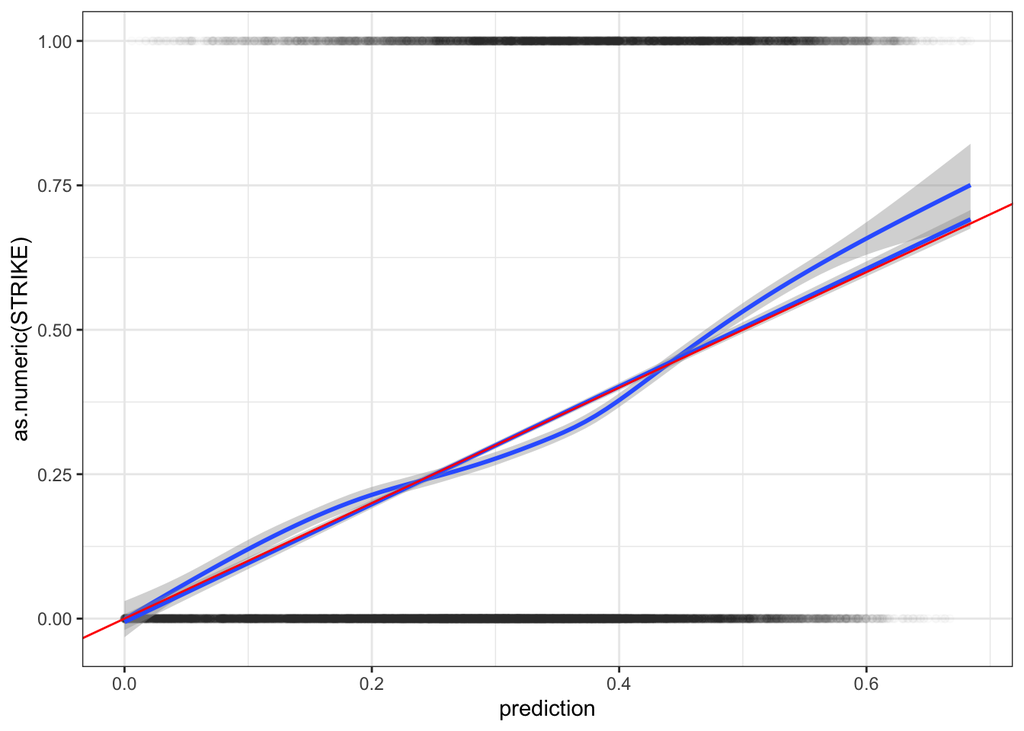

```r
# Model Predictions
sl_preds_strike <- sliders %>%
  mutate(prediction_log = predict(sl_model_strike, sliders),
         prediction = 1 / (1 + exp(-prediction_log)),
         rounded_pred = case_when(
           prediction >= 0.5 ~ 1,
           prediction < 0.5 ~ 0
         )) %>%
  filter(!is.na(prediction))

ggplot(sl_preds_strike, aes(x = prediction, y = as.numeric(STRIKE))) +
  geom_point(alpha = 0.01) +
  geom_smooth() +
  geom_smooth(method = "lm") +
  geom_abline(slope = 1, intercept = 0, color = "red") +
  theme_bw()
```

Slider Refined Model:

#### STRIKE Fastball Initial Model

```r
# Initial Model
fb_model_strike_all <- glm(STRIKE ~ pitch_speed + pfx_x + pfx_z + plate_x + plate_z + zone +
              count + pfx_total + speed_change + break_change + distance + prev_pitch +
                release_spin_rate + I(plate_x^2) + I(plate_z^2),
              data = fastballs, family = binomial)

# Model Evaluation
summary(fb_model_strike_all)
```

```
##
## Call:
## glm(formula = STRIKE ~ pitch_speed + pfx_x + pfx_z + plate_x +
##     plate_z + zone + count + pfx_total + speed_change + break_change +
##     distance + prev_pitch + release_spin_rate + I(plate_x^2) +
##     I(plate_z^2), family = binomial, data = fastballs)
##
## Coefficients:
##                       Estimate Std. Error z value Pr(>|z|)
## (Intercept)          1.370e+00  7.246e+01   0.019  0.98491
## pitch_speed          2.072e-02  5.272e-03   3.930 8.48e-05 ***
## pfx_x                1.767e-01  5.663e-02   3.120  0.00181 **
## pfx_z               -3.032e-01  7.649e-02  -3.964 7.38e-05 ***
## plate_x              3.164e-01  2.846e-02  11.117  < 2e-16 ***
## plate_z              4.221e+00  1.791e-01  23.571  < 2e-16 ***
## zone1                3.964e-02  1.872e-01   0.212  0.83233
## zone2               -5.222e-02  1.095e-01  -0.477  0.63330
## zone3                9.276e-01  1.480e-01   6.265 3.72e-10 ***
## zone4                6.503e-02  6.321e-02   1.029  0.30358
## zone6                8.772e-01  5.214e-02  16.823  < 2e-16 ***
## zone7                1.221e+00  7.641e-02  15.985  < 2e-16 ***
## zone8                9.110e-01  6.519e-02  13.974  < 2e-16 ***
## zone9                1.713e+00  6.533e-02  26.212  < 2e-16 ***
## zone11               1.544e-01  2.155e-01   0.716  0.47372
## zone12               1.056e+00  1.315e-01   8.027 9.95e-16 ***
## zone13               7.791e-01  8.977e-02   8.679  < 2e-16 ***
## zone14               3.881e-01  7.517e-02   5.163 2.43e-07 ***
## zone16               4.887e-01  5.211e-02   9.380  < 2e-16 ***
## zone17              -1.743e-02  2.102e-01  -0.083  0.93392
## count0_1            -1.029e+01  7.246e+01  -0.142  0.88704
## count0_2            -1.073e+01  7.246e+01  -0.148  0.88230
## count1_0            -9.987e+00  7.246e+01  -0.138  0.89038
## count1_1            -1.043e+01  7.246e+01  -0.144  0.88553
## count1_2            -1.068e+01  7.246e+01  -0.147  0.88287
## count2_0            -1.009e+01  7.246e+01  -0.139  0.88930
## count2_1            -1.057e+01  7.246e+01  -0.146  0.88406
## count2_2            -1.087e+01  7.246e+01  -0.150  0.88075
## count3_0            -9.006e+00  7.246e+01  -0.124  0.90109
## count3_1            -1.059e+01  7.246e+01  -0.146  0.88377
## count3_2            -1.116e+01  7.246e+01  -0.154  0.87764
## pfx_total            3.288e-01  1.200e-01   2.739  0.00616 **
## speed_change         2.053e-02  1.395e-02   1.472  0.14102
## break_change         8.842e-01  1.113e-01   7.945 1.95e-15 ***
## distance            -3.453e-01  1.766e-01  -1.956  0.05052 .
## prev_pitchFastball   5.755e-02  3.129e-02   1.839  0.06588 .
## prev_pitchNone      -9.625e+00  7.246e+01  -0.133  0.89433
## prev_pitchOff Speed  6.978e-02  6.009e-02   1.161  0.24554
## release_spin_rate    3.432e-04  7.529e-05   4.559 5.14e-06 ***
## I(plate_x^2)        -1.013e+00  5.719e-02 -17.708  < 2e-16 ***
## I(plate_z^2)        -7.249e-01  2.539e-02 -28.548  < 2e-16 ***
## ---
## Signif. codes:  0 '***' 0.001 '**' 0.01 '*' 0.05 '.' 0.1 ' ' 1
##
## (Dispersion parameter for binomial family taken to be 1)
##
##     Null deviance: 52121  on 42647  degrees of freedom
## Residual deviance: 43849  on 42607  degrees of freedom
##   (129 observations deleted due to missingness)
## AIC: 43931
##
## Number of Fisher Scoring iterations: 8
```

#### STRIKE Fastball Refined Model & Predictions

Variables Removed:

prev_pitch

speed_change

```r
# Refined Model

fb_model_strike <- glm(STRIKE ~ pitch_speed + pfx_x + pfx_z + plate_x + plate_z + zone +
              count + pfx_total + break_change + distance +
                release_spin_rate + I(plate_x^2) + I(plate_z^2),
              data = fastballs, family = binomial)

# Model Evaluation
summary(fb_model_strike)
```

```
##
## Call:
## glm(formula = STRIKE ~ pitch_speed + pfx_x + pfx_z + plate_x +
##     plate_z + zone + count + pfx_total + break_change + distance +
##     release_spin_rate + I(plate_x^2) + I(plate_z^2), family = binomial,
##     data = fastballs)
##
## Coefficients:
##                     Estimate Std. Error z value Pr(>|z|)
## (Intercept)       -8.511e+00  5.029e-01 -16.923  < 2e-16 ***
## pitch_speed        2.330e-02  4.984e-03   4.675 2.94e-06 ***
## pfx_x              1.713e-01  5.656e-02   3.028  0.00246 **
## pfx_z             -3.012e-01  7.635e-02  -3.944 8.00e-05 ***
## plate_x            3.184e-01  2.839e-02  11.215  < 2e-16 ***
## plate_z            4.238e+00  1.790e-01  23.674  < 2e-16 ***
## zone1              3.811e-02  1.873e-01   0.203  0.83877
## zone2             -5.407e-02  1.094e-01  -0.494  0.62109
## zone3              9.162e-01  1.476e-01   6.205 5.46e-10 ***
## zone4              6.555e-02  6.318e-02   1.038  0.29950
## zone6              8.782e-01  5.210e-02  16.858  < 2e-16 ***
## zone7              1.223e+00  7.635e-02  16.018  < 2e-16 ***
## zone8              9.127e-01  6.514e-02  14.011  < 2e-16 ***
## zone9              1.716e+00  6.531e-02  26.275  < 2e-16 ***
## zone11             1.546e-01  2.155e-01   0.717  0.47307
## zone12             1.068e+00  1.310e-01   8.147 3.73e-16 ***
## zone13             7.817e-01  8.973e-02   8.712  < 2e-16 ***
## zone14             3.949e-01  7.510e-02   5.258 1.46e-07 ***
## zone16             4.913e-01  5.207e-02   9.435  < 2e-16 ***
## zone17            -1.777e-02  2.102e-01  -0.085  0.93265
## count0_1          -6.267e-01  3.965e-02 -15.805  < 2e-16 ***
## count0_2          -1.044e+00  6.074e-02 -17.188  < 2e-16 ***
## count1_0          -3.209e-01  4.030e-02  -7.963 1.68e-15 ***
## count1_1          -7.668e-01  4.460e-02 -17.193  < 2e-16 ***
## count1_2          -1.003e+00  4.913e-02 -20.423  < 2e-16 ***
## count2_0          -4.223e-01  5.976e-02  -7.068 1.58e-12 ***
## count2_1          -8.957e-01  5.792e-02 -15.464  < 2e-16 ***
## count2_2          -1.196e+00  5.082e-02 -23.539  < 2e-16 ***
## count3_0           6.562e-01  8.858e-02   7.408 1.28e-13 ***
## count3_1          -9.205e-01  7.695e-02 -11.962  < 2e-16 ***
## count3_2          -1.474e+00  6.128e-02 -24.059  < 2e-16 ***
## pfx_total          3.179e-01  1.199e-01   2.651  0.00802 **
## break_change       9.068e-01  1.108e-01   8.185 2.72e-16 ***
## distance          -3.561e-01  1.764e-01  -2.018  0.04355 *
## release_spin_rate  3.455e-04  7.492e-05   4.612 3.99e-06 ***
## I(plate_x^2)      -1.010e+00  5.713e-02 -17.684  < 2e-16 ***
## I(plate_z^2)      -7.266e-01  2.538e-02 -28.626  < 2e-16 ***
## ---
## Signif. codes:  0 '***' 0.001 '**' 0.01 '*' 0.05 '.' 0.1 ' ' 1
##
## (Dispersion parameter for binomial family taken to be 1)
##
##     Null deviance: 52181  on 42689  degrees of freedom
## Residual deviance: 43907  on 42653  degrees of freedom
##   (87 observations deleted due to missingness)
## AIC: 43981
##
## Number of Fisher Scoring iterations: 6
```

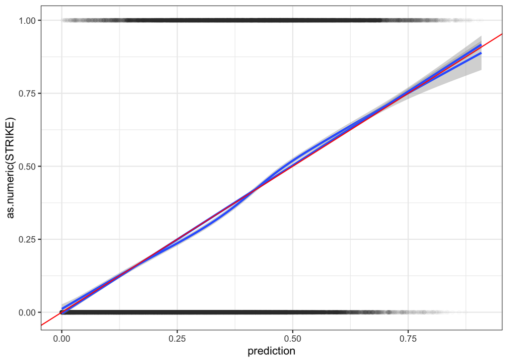

```r
# Model Predictions
fb_preds_strike <- fastballs %>%
  mutate(prediction_log = predict(fb_model_strike, fastballs),
         prediction = 1 / (1 + exp(-prediction_log)),
         rounded_pred = case_when(
           prediction >= 0.5 ~ 1,
           prediction < 0.5 ~ 0
         )) %>%
  filter(!is.na(prediction))

# fb_preds_strike %>%
#   mutate(prediction = round(prediction, 2)) %>%
#   group_by(prediction) %>%
#   summarize(n = n(), STRIKE_rate = mean(STRIKE)) %>%
#   as.data.frame() %>%
#   ggplot(aes(x = prediction, y = STRIKE_rate)) +
#   geom_point(aes(size = n)) + # size of bin shown on graph
#   coord_fixed() +
#   geom_smooth(se = FALSE) +
#   labs(y = "observed strike rate",
#        x = "projected strike rate",
#        title = "Fastball Strike Model Prediction",
#        subtitle = "Strike rate by predicted strike rate",
#        caption = "Strike rate have a 1% bin width")


ggplot(fb_preds_strike, aes(x = prediction, y = as.numeric(STRIKE))) +
  geom_point(alpha = 0.01) +
  geom_smooth() +
  geom_smooth(method = "lm") +
  geom_abline(slope = 1, intercept = 0, color = "red") +
  theme_bw()
```

Fastball Refined Model:

This model seems to be pretty accurate, including extrapolation. There is a similar, albeit slightly less pronounced, dip in prediction values between 0.3 and 0.4.